# Seguimiento de Instrucciones en Encuestas

## INTRODUCCIÓN

### 1. Contexto

En la Universidad de Ingeniería y Tecnología (UTEC), la realización de encuestas es una práctica común en los proyectos de Estadística y Probabilidades I. Sin embargo, esta tarea puede resultar desafiante para quienes se encargan de la limpieza de la base de datos, debido a que muchos estudiantes no siguen las instrucciones adecuadamente. Por esta razón, el presente estudio tiene como objetivo principal identificar el desempeño de los estudiantes en relación al seguimiento de instrucciones en el desarrollo de encuestas en la UTEC.

### 2. Relevancia

Para ello, se recopilará información de diferentes encuestas realizadas por el equipo de proyecto, incluyendo variables como el tiempo de demora en completar la encuesta, la exactitud en la respuesta de las preguntas y el cumplimiento de las instrucciones dadas. Posteriormente, se realizará un análisis estadístico para identificar patrones y tendencias en el desempeño de los estudiantes en relación al seguimiento de instrucciones, lo que permitirá identificar posibles oportunidades de mejora en la metodología de enseñanza de la UTEC. En resumen, es relevante, porque es un problema vigente y de interés.

### 3. Objetivos

#### 3.1. Objetivo general:

- Analizar el desempeño de los alumnos de la UTEC en relación con el seguimiento de instrucciones explícitas en el desarrollo de encuestas a través de Google Forms.

#### 3.2. Objetivos específicos:

- Calcular la cantidad de alumnos de la UTEC que saben seguir instrucciones explícitas en el desarrollo de encuestas.
- Identificar los principales errores y omisiones cometidos por los estudiantes en el proceso de desarrollo de encuestas.
- Relacionar la cantidad de alumnos de la UTEC que no saben seguir instrucciones con el tiempo invertido en el desarrollo de las mismas.
- Relacionar la cantidad de alumnos de la UTEC que saben seguir instrucciones con la cantidad de alumnos de la UTEC que creen que saben seguir instrucciones.
- Relacionar la cantidad de alumnos de la UTEC que saben seguir instrucciones con la cantidad de instrucciones correctamente ejecutadas y el tiempo invertido en el desarrollo total de la encuesta.

## DATOS

### 4. Marco teórico

#### 4.1. Población Objetiva

Estudiantes de la UTEC.

#### 4.2. Recolección de datos

La recolección de datos se dio a través de Google Forms. A través de el se creó una encuesta con instrucciones específicas y resaltadas en negrita en cada pregunta. Se hizo de esta manera, porque es rápido y eficiente. Además, la principal condición del forms era admitir solo direcciones de estudiantes de UTEC, la población objetivo. Finalmente, la estrategia para conseguir el mínimo de respuestas necesarias para el estudio fue el colocar como incentivo el sorteo de un combo de hamburguesas. Esto, fuera del spam entre contactos del link que contenía a la encuesta.

#### 4.3. Tipo de Muestra

La muestra seleccionada fue aleatoria. Para la construcción de la base de datos se construyó una encuesta de autoría propia.

#### 4.4. Sesgo

Sesgo de selección.

#### 4.5. Unidades muestrales

170 observaciones.

#### 4.6. Variables

[output not shown]

#### 4.7. Base de Datos

#### 4.7.1. Limpieza de la Base de Datos

##### LIMPIEZA 1

**Propósito:** Tener una base óptimamente limpia para analizar las variables relacionadas a la moda de los participantes.

```r
library(readr)
FORMS_1 <- read_csv("FORMS 1.csv")
tabla_1<-FORMS_1
tabla_1<-data.frame(cbind(tabla_1[3:15], tabla_1[19:21]))
tabla_1<-data.frame(cbind(tabla_1[1:4], tabla_1[6:16]))
names(tabla_1)<-c("Hora1","Nombre","Talla","Peso","Carrera","Cantidad1","Edad","Río","Animal", "Pisa","País","Planeta","Confirmación","Casilla","hora2")
tabla_1
```

| Hora1 | Nombre | Talla | Peso | Carrera | Cantidad1 | Edad | Río | Animal | Pisa | País | Planeta | Confirmación | Casilla | hora2 |
| --- | --- | --- | --- | --- | --- | --- | --- | --- | --- | --- | --- | --- | --- | --- |
| 18:27:00 | YADIRA DANICSA JUAREZ BOGOVICH | 110 | 63 | Bioingeniería | 1 | diecinueve | a | b | b | c | a | Sí | NA | 18:32:00 |
| 19:57:00 | BRIGITTE DAYANE ROJAS LEON | 150 | 53 | Ciencias de la computación | 1 | 18 | A | B | B | B | A | Sí | Sí | 20:00:00 |
| 22:26:00 | DARCIE SOL AYALA TAPIA | 152 | 56 | Ingeniería mecánica | 4 | dieciocho | A | B | B | C | C | Sí | NA | 22:32:00 |
| 07:57:00 | Caroline Jazmín Crisóstomo Huiza | 154 | 60 | Ingeniería Civil | 4 | 19 | A | B | B | C | C | Sí | NA | 08:02:00 |
| 16:11:00 | Alessandra Paula Suarez Paz | 155 | 52 | Bioingeniería | 6 | 20 | A | B | A | C | C | Sí | NA | 16:17:00 |
| 20:01:00 | SHARON ALEJANDRA AIQUIPA MEZA | 157 | 48 | Ingeniería Mecatrónica | 2 | dieciocho | A | B | B | C | C | Sí | NA | 20:05:00 |
| 20:49:00 | HENRY ANDERSON GAHONA LÓPEZ | 159 | 63 | Ingeniería electrónica | 4 | dieciocho | a | b | b | c | c | Sí | NA | 20:54:00 |
| 12:28:00 | DANIELA ROMINA TITO BUSTIOS | 159 | 60 | Ingeniería electrónica | 4 | veinte | a | b | b | c | c | Sí | NA | 12:34:00 |
| 07:32:00 | LUZ ANGHELA FLORES FERNÁNDEZ | 160 | 54 | Bioingeniería | 3 | 19 | a | b | b | c | c | Sí | NA | 07:40:00 |
| 20:55:00 | RAFAEL OLIVERTH SOLIER SOTO | 162 | 60 | Ingeniería Electrónica | 4 | Diecinueve | a | b | b | c | a | Sí | NA | 21:01:00 |

[output cut: 160 more lines]

**Limpieza Nombre**

```r
library(stringr)
tabla_1$Nombre <- str_to_title(tabla_1$Nombre)
```

**Limpieza talla**

```r
tabla_1$Talla <- gsub("[^[:digit:]]", "", tabla_1$Talla)
tabla_1$Talla[tabla_1$Talla == "37"]<- NA
tabla_1$Talla[tabla_1$Talla == "285"]<- 185
tabla_1$Talla[tabla_1$Talla == "17"]<- 170
```

**Limpieza Peso**

```r
filas <- c(48,62)
tabla_1[filas,4] <- NA
filas <- c(71)
tabla_1[filas,4] <- 76
tabla_1$Peso[tabla_1$Peso == "854"]<- NA
tabla_1$Peso[tabla_1$Peso == "675"]<- 75
tabla_1$Peso[tabla_1$Peso == "642"]<- 64
tabla_1$Peso[tabla_1$Peso == "854"]<- 85
tabla_1$Peso <- gsub("[^[:digit:]]", "", tabla_1$Peso)
```

**Limpieza Hora 1**

```r
tabla_1$Hora1[tabla_1$Hora1 == "18300"]<- 61500
tabla_1$Hora1[tabla_1$Hora1 == "4260"]<- 47460
tabla_1$Hora1[tabla_1$Hora1 == "0"]<- 32400
tabla_1$Hora1[tabla_1$Hora1 == "8820"]<- 52020
#Consulta-Yared
tabla_1$Hora1[tabla_1$Hora1 == "28740"]<- 35940
tabla_1$Hora1[tabla_1$Hora1 == "3600"]<- 46800
```

**Limpieza Hora 2**

```r
tabla_1$hora2[tabla_1$hora2 == "26040"]<- 69240
tabla_1$hora2[tabla_1$hora2 == "6240"]<- 49440
tabla_1$hora2[tabla_1$hora2 == "3780"]<- 46980
tabla_1$hora2[tabla_1$hora2 == "37620"]<- 80820
tabla_1$hora2[tabla_1$hora2 == "11820"]<- 55022
```

**Limpieza Carrera**

```r
tabla_1$Carrera <- str_to_title(tabla_1$Carrera)
tabla_1$Carrera[tabla_1$Carrera == "Civil"]<- "Ingeniería Civil"
tabla_1$Carrera[tabla_1$Carrera == "Ing. Civil"]<- "Ingeniería Civil"
tabla_1$Carrera[tabla_1$Carrera == "Ing. Civil"]<- "Ingeniería Civil"
tabla_1$Carrera[tabla_1$Carrera == "Ingenería Química"]<- "Ingeniería Química"
tabla_1$Carrera[tabla_1$Carrera == "Química"]<- "Ingeniería Química"
tabla_1$Carrera[tabla_1$Carrera == "Ing. Química"]<- "Ingeniería Química"
tabla_1$Carrera[tabla_1$Carrera == "Ing Ambiental"]<- "Ingeniería Ambiental"
tabla_1$Carrera[tabla_1$Carrera == "Ing. Ambiental"]<- "Ingeniería Ambiental"
tabla_1$Carrera[tabla_1$Carrera == "Ingenieria Ambiental"]<- "Ingeniería Ambiental"
tabla_1$Carrera[tabla_1$Carrera == "Ambiental"]<- "Ingeniería Ambiental"
tabla_1$Carrera[tabla_1$Carrera == "Mecánica"]<- "Ingeniería Mecánica"
tabla_1$Carrera[tabla_1$Carrera == "Mecatrónica"]<- "Ingeniería Mecatrónica"
tabla_1$Carrera[tabla_1$Carrera == "Electrónica"]<- "Ingeniería Electrónica"
tabla_1$Carrera[tabla_1$Carrera == "Ing. Electrónica"]<- "Ingeniería Electrónica"
tabla_1$Carrera[tabla_1$Carrera == "Ingeniería De Energía"]<- "Ingeniería De La Energía"
tabla_1$Carrera[tabla_1$Carrera == "Industrial"]<- "Ingeniería Industrial"
tabla_1$Carrera[tabla_1$Carrera == "Futbolista"]<- NA
```

**Limpieza Cantidad**

```r
tabla_1$Cantidad1 <- gsub("[^[:digit:]]", "", tabla_1$Cantidad1)
tabla_1$Cantidad1[tabla_1$Cantidad1 == "Cinco"]<- 5
tabla_1$Cantidad1[tabla_1$Cantidad1 == ""]<- NA
unique(tabla_1$Cantidad1)
```

```
## [1] "1" "4" "6" "2" "3" "0" "5" NA
```

**Limpieza Edad**

```r
tabla_1$Edad <- str_to_title(tabla_1$Edad)
tabla_1$Edad[tabla_1$Edad == "Dieciséis"]<- 16
tabla_1$Edad[tabla_1$Edad == "Diecisiete"]<- 17
tabla_1$Edad[tabla_1$Edad == "Diecisite"]<- 17
tabla_1$Edad[tabla_1$Edad == "Dieciocho"]<- 18
tabla_1$Edad[tabla_1$Edad == "Diecinueve"]<- 19
tabla_1$Edad[tabla_1$Edad == "Veinte"]<- 20
tabla_1$Edad[tabla_1$Edad == "Veintiuno"]<- 21
tabla_1$Edad[tabla_1$Edad == "Veintidos"]<- 22
tabla_1$Edad[tabla_1$Edad == "Veintidós"]<- 22
tabla_1$Edad[tabla_1$Edad == "Veintitrés"]<- 23
tabla_1$Edad[tabla_1$Edad == "Veinticuatro"]<- 24
unique(tabla_1$Edad)
```

```
##  [1] "19" "18" "20" "21" "23" "17" "22" "25" "24" "16" "26"
```

**Limpieza Río**

```r
tabla_1$Río <- str_to_title(tabla_1$Río)
tabla_1$Río[tabla_1$Río == "Amazonas"]<-"B"
tabla_1$Río[tabla_1$Río == "B) Amazonas"]<-"B"
tabla_1$Río[tabla_1$Río == "Amazones"]<-"B"
tabla_1$Río[tabla_1$Río == "Nilo"]<-"A"
unique(tabla_1$Río)
```

```
## [1] "A" "B" "C"
```

**Limpieza Animal**

```r
tabla_1$Animal <- str_to_title(tabla_1$Animal)
tabla_1$Animal[tabla_1$Animal == "Mamífero"]<-"B"
tabla_1$Animal[tabla_1$Animal == "Mamifero"]<-"B"
tabla_1$Animal[tabla_1$Animal == "B) Mamífero"]<-"B"
tabla_1$Animal[tabla_1$Animal == "M"]<-"B"
tabla_1$Animal[tabla_1$Animal == "Pez"]<-"A"
unique(tabla_1$Animal)
```

```
## [1] "B" "C" "A"
```

**Limpieza Pisa**

```r
tabla_1$Pisa <- str_to_title(tabla_1$Pisa)
tabla_1$Pisa[tabla_1$Pisa == "Italia"]<-"B"
tabla_1$Pisa[tabla_1$Pisa == "B)Italia"]<-"B"
tabla_1$Pisa[tabla_1$Pisa == "B) Italia"]<-"B"
tabla_1$Pisa[tabla_1$Pisa == "Francia"]<-"A"
tabla_1$Pisa[tabla_1$Pisa == "España"]<-"C"
unique(tabla_1$Pisa)
```

```
## [1] "B" "A" "C"
```

**Limpieza País**

```r
tabla_1$País <- str_to_title(tabla_1$País)
tabla_1$País[tabla_1$País == "Rusia"]<-"C"
tabla_1$País[tabla_1$País == "C) Rusia"]<-"C"
tabla_1$País[tabla_1$País == "C)Rusia"]<-"C"
tabla_1$País[tabla_1$País == "Russia"]<-"C"
tabla_1$País[tabla_1$País == "R"]<-"C"
tabla_1$País[tabla_1$País == "Brazil"]<-"A"
tabla_1$País[tabla_1$País == "China"]<-"B"
tabla_1$País[tabla_1$País == "G"]<-NA
unique(tabla_1$País)
```

```
## [1] "C" "B" "A" NA
```

**Limpieza Planeta**

```r
tabla_1$Planeta <- str_to_title(tabla_1$Planeta)
tabla_1$Planeta[tabla_1$Planeta == "C) Neptuno"]<-"C"
tabla_1$Planeta[tabla_1$Planeta == "A)Saturno"]<-"A"
tabla_1$Planeta[tabla_1$Planeta == "S"]<-"A"
tabla_1$Planeta[tabla_1$Planeta == "Saturno"]<-"A"
tabla_1$Planeta[tabla_1$Planeta == "Neptuno"]<-"C"
tabla_1$Planeta[tabla_1$Planeta == "Nepturno"]<-"C"
tabla_1$Planeta[tabla_1$Planeta == "N"]<-"C"
tabla_1$Planeta[tabla_1$Planeta == "Mercurio"]<-"B"
unique(tabla_1$Planeta)
```

```
## [1] "A" "C" "B"
```

**Saltar instrucción**

```r
tabla_1$Casilla[is.na(tabla_1$Casilla)] <- "No"
tabla_1$Confirmación[is.na(tabla_1$Confirmación)] <- "No"
```

**Revisión**

```r
#Pasar a numéricas
tabla_1$Talla <- as.numeric(tabla_1$Talla)
tabla_1$Peso <- as.numeric(tabla_1$Peso)
tabla_1$Cantidad1 <- as.numeric(tabla_1$Cantidad1)
tabla_1$Edad <- as.numeric(tabla_1$Edad)
#Restar las horas para ver cuánto demoraron
tabla_1$DiferenciaHora <- tabla_1$hora2 - tabla_1$Hora1
#Limpiar Nueva casilla
tabla_1$DiferenciaHora <- ifelse(tabla_1$DiferenciaHora < 0, NA, tabla_1$DiferenciaHora)
tabla_1$DiferenciaHora <- ifelse(tabla_1$DiferenciaHora > 3600, NA, tabla_1$DiferenciaHora)
#____________________________________________________________________
nrow(tabla_1) #Cuenta número de filas (observaciones, muestra)
```

```
## [1] 170
```

```r
ncol(tabla_1) #Cuenta número de columnas (variables)
```

```
## [1] 16
```

```r
sum(is.na(tabla_1)) #Suma las celdas vacías de DF (Datos faltantes)
```

```
## [1] 9
```

```r
sum(!complete.cases(tabla_1)) #Suma las observaciones incompletas
```

```
## [1] 9
```

##### LIMPIEZA 2

Limpieza hecha para contar la cantidad de personas que saben contestar una encuesta y desarrollar los objetivos específicos:

```r
tabla_2<-FORMS_1
tabla_2<-data.frame(tabla_2[3:21])
names(tabla_2)<-c("Horai24","Nombremay","Tallacm","Pesokg","Fechamda","Carreracom","Vecesnum","Edadmin","Río","Animal", "Pisa","País","Planeta","Pregunta1","Pregunta2","Pregunta3","Confirmación","Saltodeinst","Horaf24")
tabla_2
```

| Horai24 | Nombremay | Tallacm | Pesokg | Fechamda | Carreracom | Vecesnum | Edadmin | Río | Animal | Pisa | País | Planeta | Pregunta1 | Pregunta2 | Pregunta3 | Confirmación | Saltodeinst | Horaf24 |
| --- | --- | --- | --- | --- | --- | --- | --- | --- | --- | --- | --- | --- | --- | --- | --- | --- | --- | --- |
| 18:27:00 | YADIRA DANICSA JUAREZ BOGOVICH | 110 | 63 | 24/33/2004 | Bioingeniería | 1 | diecinueve | a | b | b | c | a | LE ESCRIBIO UN MENSAJE CON EL FIN DE ENCONTRARSE CON LA PERSONA | EN LA CAFETERÍA CERCA DE LA PLAZA | SÍ | Sí | NA | 18:32:00 |
| 19:57:00 | BRIGITTE DAYANE ROJAS LEON | 150 | 53 | 15/06/2004 | Ciencias de la computación | 1 | 18 | A | B | B | B | A | me mandó un mensaje | en la cafeteria que esta cerca a la plaza | si | Sí | Sí | 20:00:00 |
| 22:26:00 | DARCIE SOL AYALA TAPIA | 152 | 56 | 10/23/2004 | Ingeniería mecánica | 4 | dieciocho | A | B | B | C | C | envió un mensaje | en la cafetería | sí | Sí | NA | 22:32:00 |
| 07:57:00 | Caroline Jazmín Crisóstomo Huiza | 154 | 60 | 23/10/2001 | Ingeniería Civil | 4 | 19 | A | B | B | C | C | Me invitó a tomar café | En la cafetería cerca de la plaza | Si | Sí | NA | 08:02:00 |
| 16:11:00 | Alessandra Paula Suarez Paz | 155 | 52 | 11/05/2002 | Bioingeniería | 6 | 20 | A | B | A | C | C | Mensajearme con el propósito de decirme de que quería reunirse conmigo para tomar un café. | En la cafeteria cerca de la plaza | Si | Sí | NA | 16:17:00 |
| 20:01:00 | SHARON ALEJANDRA AIQUIPA MEZA | 157 | 48 | 08/03/2004 | Ingeniería Mecatrónica | 2 | dieciocho | A | B | B | C | C | ME MANDÓ UN MENSAJE | EN LA CAFETERÍA CERCA DE LA PLAZA | SÍ | Sí | NA | 20:05:00 |
| 20:49:00 | HENRY ANDERSON GAHONA LÓPEZ | 159 | 63 | 04/21/2004 | Ingeniería electrónica | 4 | dieciocho | a | b | b | c | c | Me dijo que quería reunirse conmigo. | En la cafetería que está cerca de la plaza. | Sí | Sí | NA | 20:54:00 |
| 12:28:00 | DANIELA ROMINA TITO BUSTIOS | 159 | 60 | 07/04/2002 | Ingeniería electrónica | 4 | veinte | a | b | b | c | c | Me invito a tomar café | En la cafetería cerca a la plaza | Si | Sí | NA | 12:34:00 |
| 07:32:00 | LUZ ANGHELA FLORES FERNÁNDEZ | 160 | 54 | 01/17/2004 | Bioingeniería | 3 | 19 | a | b | b | c | c | Escribir un mensaje de texto | Cafetería | Si | Sí | NA | 07:40:00 |
| 20:55:00 | RAFAEL OLIVERTH SOLIER SOTO | 162 | 60 | 11/21/2003 | Ingeniería Electrónica | 4 | Diecinueve | a | b | b | c | a | ME ESCRIBIÓN UN MENSAJE DE TEXTO PARA DECIRME QUE SE QUERÍA REUNIR CONMIGO PARA TOMAR UN CAFÉ | EN LA CAFETERÍA DE CERCA DE LA PLAZA | SÍ, Y PUNTUALMENTE | Sí | NA | 21:01:00 |

[output cut: 160 more lines]

**Limpieza hora inicial formato 24 horas**

```r
# Reemplazar los valores en las filas mal ingresadas de la columna 1 (Hora incial, formato 24 horas) por NA
filas <- c(4,9,31,33,38,41,42,44,74,75,79,81,82,87,88,92,95,102,108,127,131,135,138,142,161,167)
tabla_2[filas,1] <- NA
```

**Limpieza nombre**

```r
#Elimina lo que no sea solo mayúsculas
tabla_2$Nombremay <- sapply(strsplit(as.character(tabla_2$Nombremay), "\\s+"), function(x) ifelse(!all(grepl("^[[:upper:]]+$", x)), NA, paste(x, collapse = " ")))
```

**Limpieza talla**

```r
tabla_2$Tallacm[tabla_2$Tallacm == "150 cm"]<- 150
tabla_2$Tallacm[tabla_2$Tallacm == "176cm"]<- 176
tabla_2$Tallacm[tabla_2$Tallacm == "Ciento setenta (170)"]<- 176
tabla_2$Tallacm <- ifelse(tabla_2$Tallacm < 100, NA, tabla_2$Tallacm)
tabla_2$Tallacm[tabla_2$Tallacm == "28.5"]<- NA
tabla_2$Tallacm[tabla_2$Tallacm == "37"]<- NA
```

**Limpieza peso**

```r
tabla_2$Pesokg[tabla_2$Pesokg == "48kg"]<- 48
tabla_2$Pesokg[tabla_2$Pesokg == "65kg"]<- 65
tabla_2$Pesokg[tabla_2$Pesokg == "Sesenta y seis (66)"]<- 66
```

**Limpieza fecha de nacimiento en formato mm/dd/aa**

```r
tabla_2$Fechamda[tabla_2$Fechamda == "24/33/2004"]<- NA
tabla_2$Fechamda[tabla_2$Fechamda == "15/06/2004"]<- NA
tabla_2$Fechamda[tabla_2$Fechamda == "05/04/2023"]<- 05/04/2003
tabla_2$Fechamda[tabla_2$Fechamda == "07-07-2004"]<- 07/07/2004
tabla_2$Fechamda[tabla_2$Fechamda == "01312001"]<- 01/31/2001
tabla_2$Fechamda[tabla_2$Fechamda == "29.11.2000"]<- NA
tabla_2$Fechamda[tabla_2$Fechamda == "11122003"]<- 11/12/2003
tabla_2$Fechamda[tabla_2$Fechamda == "07112002"]<- 07/11/2002
#Anulo el siguiente, porque el mes está mal
tabla_2$Fechamda[tabla_2$Fechamda == "25/09/97"]<- NA
# Convertir fechas a números y verificar condición
tabla_2$Fechamda <- ifelse(as.numeric(substr(tabla_2$Fechamda, 1, 2)) <= 12, tabla_2$Fechamda, NA)
```

**Limpieza de nombre completo de carrera**

```r
library(stringr)
tabla_2$Carreracom <- str_to_title(tabla_2$Carreracom)
tabla_2$Carreracom <- str_to_title(tabla_2$Carreracom)
tabla_2$Carreracom[tabla_2$Carreracom == "Ingeneria Química"]<- "Ingeniería Química"
tabla_2$Carreracom[tabla_2$Carreracom == "Ingenieria Ambiental"]<- "Ingeniería Ambiental"
tabla_2$Carreracom[tabla_2$Carreracom == "Ingeniería De Energía"]<- "Ingeniería De La Energía"
tabla_2$Carreracom[tabla_2$Carreracom == "Civil"]<- NA
tabla_2$Carreracom[tabla_2$Carreracom == "Ing. Civil"]<- NA
tabla_2$Carreracom[tabla_2$Carreracom == "Ing Civil"]<- NA
tabla_2$Carreracom[tabla_2$Carreracom == "Química"]<- NA
tabla_2$Carreracom[tabla_2$Carreracom == "Ing. Química"]<- NA
tabla_2$Carreracom[tabla_2$Carreracom == "Ing Ambiental"]<- NA
tabla_2$Carreracom[tabla_2$Carreracom == "Ing. Ambiental"]<- NA
tabla_2$Carreracom[tabla_2$Carreracom == "Ambiental"]<- NA
tabla_2$Carreracom[tabla_2$Carreracom == "Mecánica"]<- NA
tabla_2$Carreracom[tabla_2$Carreracom == "Mecatrónica"]<- NA
tabla_2$Carreracom[tabla_2$Carreracom == "Electrónica"]<- NA
tabla_2$Carreracom[tabla_2$Carreracom == "Ing. Electrónica"]<- NA
tabla_2$Carreracom[tabla_2$Carreracom == "Industrial"]<- NA
tabla_2$Carreracom[tabla_2$Carreracom == "Futbolista"]<- NA
```

**Limpieza de veces que van a la univrersidad en números**

```r
tabla_2$Vecesnum[tabla_2$Vecesnum == "5 veces"]<- 5
tabla_2$Vecesnum[tabla_2$Vecesnum == "Cinco"]<- NA
```

**Limpieza edad en minúsculas**

```r
#El código elimina todo lo que no es minúscula
tabla_2$Edadmin <- sapply(strsplit(as.character(tabla_2$Edadmin), "\\s+"), function(x) ifelse(!all(grepl("^[[:lower:]]+$", x)), NA, paste(x, collapse = " ")))
```

**Limpieza pregunta de opción múltiple**

```r
#Río más largo del mundo
tabla_2$Río <- sapply(strsplit(as.character(tabla_2$Río), "\\s+"), function(x) ifelse(!all(grepl("^[[:lower:]]+$", x)), NA, paste(x, collapse = " ")))
#Tipo de animal que es la ballena
tabla_2$Animal <- sapply(strsplit(as.character(tabla_2$Animal), "\\s+"), function(x) ifelse(!all(grepl("^[[:lower:]]+$", x)), NA, paste(x, collapse = " ")))
#Páis de la torre de Pisa
tabla_2$Pisa <- sapply(strsplit(as.character(tabla_2$Pisa), "\\s+"), function(x) ifelse(!all(grepl("^[[:lower:]]+$", x)), NA, paste(x, collapse = " ")))
#País más grande
tabla_2$País <- sapply(strsplit(as.character(tabla_2$País), "\\s+"), function(x) ifelse(!all(grepl("^[[:lower:]]+$", x)), NA, paste(x, collapse = " ")))
#Planeta
tabla_2$Planeta <- sapply(strsplit(as.character(tabla_2$Planeta), "\\s+"), function(x) ifelse(!all(grepl("^[[:lower:]]+$", x)), NA, paste(x, collapse = " ")))
```

**Limpieza preguntas abiertas en mayúsculas**

```r
#Pregunta 1
#Elimina lo que no sea solo mayúsculas
tabla_2$Pregunta1 <- sapply(strsplit(as.character(tabla_2$Pregunta1), "\\s+"), function(x) ifelse(!all(grepl("^[[:upper:]]+$", x)), NA, paste(x, collapse = " ")))
#Pregunta 2
#Elimina lo que no sea solo mayúsculas
tabla_2$Pregunta2 <- sapply(strsplit(as.character(tabla_2$Pregunta2), "\\s+"), function(x) ifelse(!all(grepl("^[[:upper:]]+$", x)), NA, paste(x, collapse = " ")))
#Pregunta 3
#Elimina lo que no sea solo mayúsculas
tabla_2$Pregunta3 <- sapply(strsplit(as.character(tabla_2$Pregunta3), "\\s+"), function(x) ifelse(!all(grepl("^[[:upper:]]+$", x)), NA, paste(x, collapse = " ")))
```

**Limpieza hora final formato 24 horas**

```r
# Reemplazar los valores en las filas mal ingresadas de la columna 1 (Hora incial, formato 24 horas) por NA
filas <- c(4,9,26,31,33,38,42,60,74,75,79,81,82,87,88,92,95,127,128,134,135,138,142,157,161,167)
tabla_2[filas,19] <- NA
```

**COLUMNAS EXTRA**

```r
#ACIERTOS
tabla_2$Aciertos <- rowSums(!is.na(tabla_2))
#DESACIERTOS
tabla_2$Desaciertos <- rowSums(is.na(tabla_2))
```

## ANÁLISIS DESCRIPTIVO

### 5. Metodología y Resultados

#### 5.1 Descriptores

##### 5.1.1 Descriptores numéricos de posición

Son medidas estadísticas que representan la ubicación o posición relativa de un conjunto de datos en relación con otros valores. Estos descriptores proporcionan información sobre dónde se encuentran los valores en la distribución de los datos y ayudan a comprender la concentración y dispersión de los mismos.

```
##            Talla  Peso  Cantidad1 Edad  Tiempo
## Min        110    40    0         16    60
## Max        193    180   6         26    2400
## Media      166.54 66.67 2.91      19.74 360.37
## Mediana    168    64    3         20    300
## Desviacion 10.28  16.52 1.55      1.72  281.07
## CV         0.06   0.25  0.53      0.09  0.78
```

**TALLA**

| DESCRIPTOR NUMÉRICO | Talla |
| --- | --- |
| Min | 110 |
| Max | 193 |
| Media | 166.54 |
| Mediana | 168 |
| Desviación | 10.28 |
| CV | 0.06 |

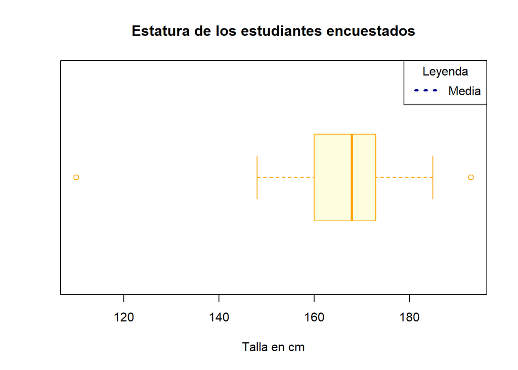

- **Análisis descriptivo:**

  El boxplot representa para la variable talla:
  - **Min:** Es el valor mínimo de la variable en el conjunto de datos. En este caso, indica que la menor talla registrada es 110 cm.
  - **Max:** Es el valor máximo de la variable en el conjunto de datos. En este caso, indica que la mayor talla registrada es 193 cm.
  - **Media:** Es el promedio aritmético de los valores de la variable en el conjunto de datos. Se calcula sumando todos los valores y dividiendo entre el número total de datos. En este caso, indica que la talla promedio es 166.54 cm.
  - **Mediana:** Es el valor que ocupa el lugar central de la variable en el conjunto de datos ordenados de menor a mayor. Si hay un número par de datos, se toma el promedio de los dos valores centrales. En este caso, indica que la mitad de las personas tienen una talla menor o igual a 168 cm y la otra mitad tiene una talla mayor o igual a 168 cm.
  - **Desviación:** Es una medida de la variabilidad o dispersión de los valores de la variable en el conjunto de datos. Se calcula como la raíz cuadrada de la varianza, que es el promedio de las diferencias al cuadrado entre cada valor y la media. En este caso, indica que la talla varía en promedio 10.28 cm respecto a la media.
  - **CV:** Es el coeficiente de variación, que se calcula como el cociente entre la desviación y la media, expresado en porcentaje. Es una medida relativa de la variabilidad o dispersión de los valores de la variable en el conjunto de datos. En este caso, un CV de 0.06 indica que la variabilidad relativa de la estatura en la base de datos es del 6%. Un CV bajo sugiere que los valores de estatura están relativamente cerca de la media, lo que indica una menor variabilidad en la estatura de las personas en la base de datos.

    Encontramos 2 datos atípicos.

**PESO**

| DESCRIPTOR NUMÉRICO | Peso |
| --- | --- |
| Min | 40 |
| Max | 180 |
| Media | 66.67 |
| Mediana | 64 |
| Desviación | 16.52 |
| CV | 0.25 |

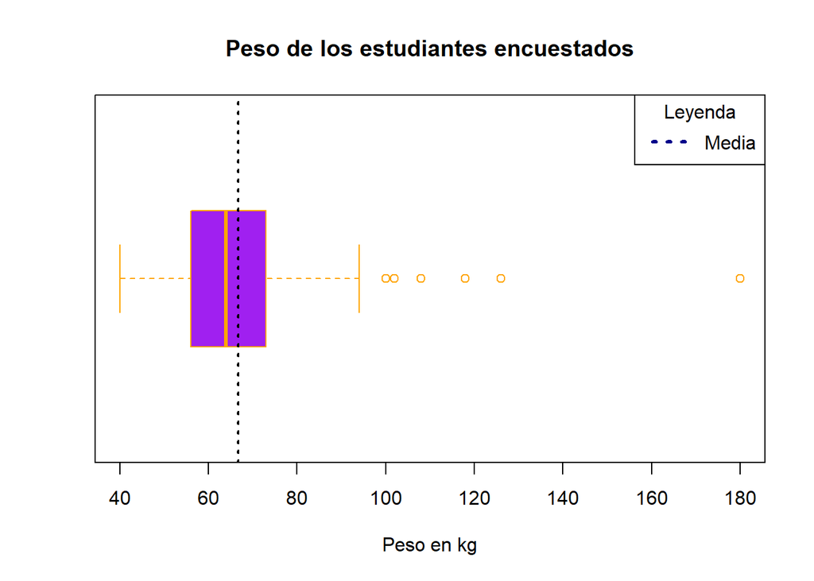

- **Análisis descriptivo:**

  El boxplot nos permite identificar lo siguiente:
  - **Min:** El valor mínimo de la variable “peso” es 40 kg. Esto significa que al menos una persona en la base de datos tiene un peso de 40 kg.
  - **Max:** El valor máximo de la variable “peso” es 180 kg. Esto indica que al menos una persona en la base de datos tiene un peso de 180 kg, que es el peso más alto registrado.
  - **Media:** La media de la variable “peso” es 66.67 kg. Esto implica que, en promedio, las personas en la base de datos tienen un peso de aproximadamente 66.67 kg.
  - **Mediana:** La mediana de la variable “peso” es 64 kg. La mediana es el valor que se encuentra en el medio de todos los datos cuando se ordenan de forma ascendente. Esto significa que la mitad de las personas en la base de datos tienen un peso igual o menor a 64 kg, y la otra mitad tiene un peso igual o mayor a 64 kg.
  - **Desviación estándar:** La desviación estándar de la variable “peso” es 16.52 kg. La desviación estándar es una medida de dispersión que indica cuánto se desvían los valores individuales de la media. En este caso, la desviación estándar de 16.52 kg implica que los valores de peso tienden a dispersarse alrededor de la media de 66.67 kg.
  - **Coeficiente de Variación:** El coeficiente de variación de la variable “peso” es 0.25. El CV se calcula como la desviación estándar dividida por la media, y se expresa como un porcentaje. En este caso, un CV de 0.25 indica que la variabilidad relativa del peso en la base de datos es del 25%. Un CV moderado sugiere que los valores de peso presentan cierta variabilidad en relación con la media.

    Encontramos 6 datos atípicos para esta variable.

**CANTIDAD DE VECES QUE VA A LA UNIVERSIDAD**

| DESCRIPTOR NUMÉRICO | Cantidad de veces que va a la universidad |
| --- | --- |
| Min | 0 |
| Max | 6 |
| Media | 2.91 |
| Mediana | 3 |
| Desviación | 1.55 |
| CV | 0.53 |

[figure not shown]

- **Análisis descriptivo:**

  El boxplot nos facilita la siguiente información:
  - **Min:** El valor mínimo de la variable “Cantidad de veces que va a la universidad” es 0. Esto significa que al menos una persona en la base de datos no ha ido a la universidad.
  - **Max:** El valor máximo de la variable “Cantidad de veces que va a la universidad” es 6. Esto indica que al menos una persona en la base de datos ha ido a la universidad 6 veces.
  - **Media:** La media de la variable “Cantidad de veces que va a la universidad” es 2.91. Esto implica que, en promedio, las personas en la base de datos han ido a la universidad aproximadamente 2.91 veces.
  - **Mediana:** La mediana de la variable “Cantidad de veces que va a la universidad” es 3. La mediana es el valor que se encuentra en el medio de todos los datos cuando se ordenan de forma ascendente. Esto significa que la mitad de las personas en la base de datos han ido a la universidad igual o menos de 3 veces, y la otra mitad ha ido igual o más de 3 veces.
  - **Desviación estándar:** La desviación estándar de la variable “Cantidad de veces que va a la universidad” es 1.55. La desviación estándar es una medida de dispersión que indica cuánto se desvían los valores individuales de la media. En este caso, la desviación estándar de 1.55 implica que los valores de la cantidad de veces que se va a la universidad tienden a dispersarse alrededor de la media de 2.91.
  - **Coeficiente de Variación:** El coeficiente de variación de la variable “Cantidad de veces que va a la universidad” es 0.53. El CV se calcula como la desviación estándar dividida por la media, y se expresa como un porcentaje. En este caso, un CV de 0.53 indica que la variabilidad relativa de la cantidad de veces que se va a la universidad en la base de datos es del 53%. Un CV moderado sugiere que los valores de esta variable presentan cierta variabilidad en relación con la media.

    No tenemos datos atípicos.

**EDAD**

| DESCRIPTOR NUMÉRICO | Edades |
| --- | --- |
| Min | 16 |
| Max | 26 |
| Media | 19.74 |
| Mediana | 20 |
| Desviación | 1.72 |
| CV | 0.09 |

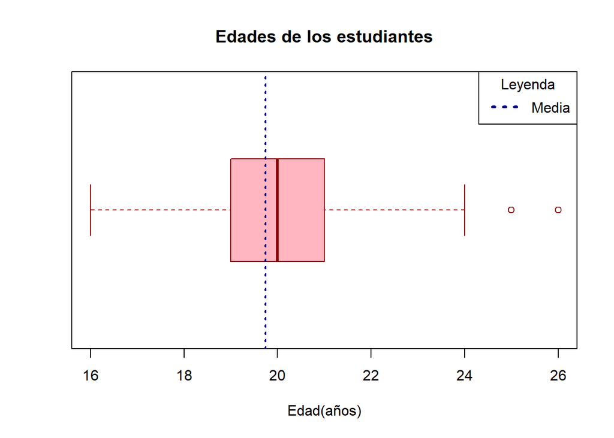

- **Análisis descriptivo:**

  El boxplot nos proporciona la siguiente información en relación con la variable analizada:
  - **Min:** El valor mínimo de la variable “Edades” es 16 años. Esto significa que al menos una persona en la base de datos tiene 16 años.
  - **Max:** El valor máximo de la variable “Edades” es 26 años. Esto indica que al menos una persona en la base de datos tiene 26 años, que es la edad máxima registrada.
  - **Media:** La media de la variable “Edades” es 19.74 años. Esto implica que, en promedio, las personas en la base de datos tienen una edad de aproximadamente 19.74 años.
  - **Mediana:** La mediana de la variable “Edades” es 20 años. La mediana es el valor que se encuentra en el medio de todos los datos cuando se ordenan de forma ascendente. Esto significa que la mitad de las personas en la base de datos tienen una edad igual o menor a 20 años, y la otra mitad tiene una edad igual o mayor a 20 años.
  - **Desviación estándar:** La desviación estándar de la variable “Edades” es 1.72 años. La desviación estándar es una medida de dispersión que indica cuánto se desvían los valores individuales de la media. En este caso, la desviación estándar de 1.72 años implica que los valores de edad tienden a dispersarse alrededor de la media de 19.74 años.
  - **Coeficiente de Variación:** El coeficiente de variación de la variable “Edades” es 0.09. El CV se calcula como la desviación estándar dividida por la media, y se expresa como un porcentaje. En este caso, un CV de 0.09 indica que la variabilidad relativa de las edades en la base de datos es del 9%. Un CV bajo sugiere que los valores de edad están relativamente cerca de la media, lo que indica una menor variabilidad en las edades de las personas en la base de datos.

    Tenemos 2 datos atípicos.

**Tiempo**

| DESCRIPTOR NUMÉRICO | Tiempo invertido |
| --- | --- |
| Min | 60 |
| Max | 2400 |
| Media | 360.37 |
| Mediana | 300 |
| Desviación | 281.07 |
| CV | 0.78 |

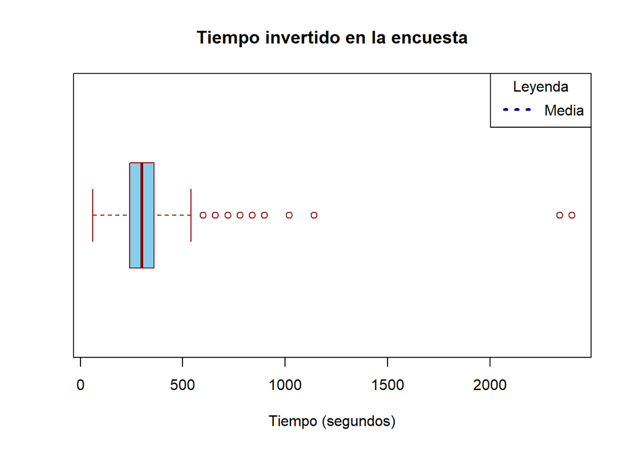

- **Análisis descriptivo:**

##### 5.1.2. Descriptores gráficos

*Alineación a los objetivos*

**i. Calcular la cantidad de alumnos de la UTEC que saben seguir instrucciones explícitas en el desarrollo de encuestas.**

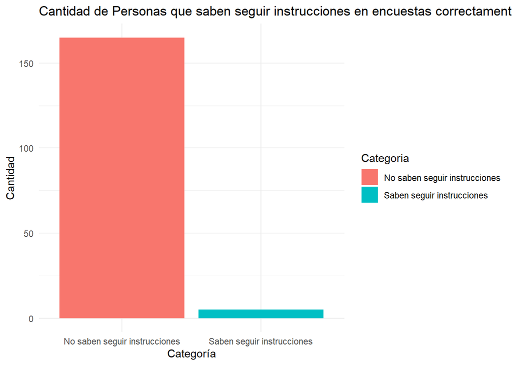

- **Análisis descriptivo:**

  El gráfico de barras nos muestra una gran diferencia entre la cantidad de personas que saben seguir instrucciones y las que no. Se contó como personas que no saben seguir instrucciones a las que tenían más de un dato faltante por fila. Por lo tanto, respondiendo al objetivo, la cantidad de alumnos de la UTEC que saben seguir instrucciones explícitas en el desarrollo de encuestas es 5. Es decir, el 2.94%.

**ii. Identificar los principales errores y omisiones cometidos por los estudiantes en el proceso de desarrollo de encuestas.**

**- ACIERTOS:**

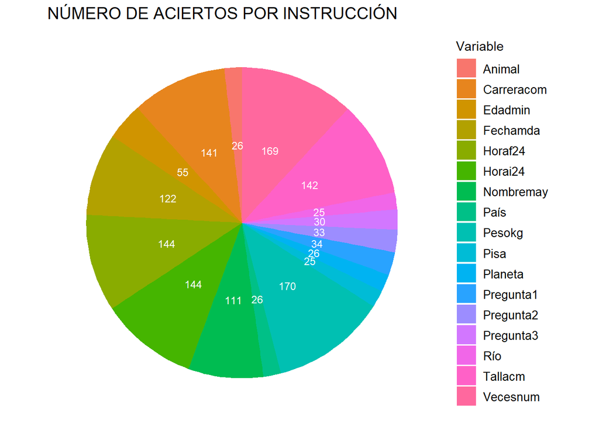

- **Análisis descriptivo:**

  El gráfico circular representa la porción de aciertos por instrucción en la encuesta. En este sentido, las 5 instrucciones con más aciertos son, de más a menos aciertos: Pesokg (Ingresar el peso en kg), Vecesnum (Ingresar como número entero las veces que van a la universidad), Horaf24 y Horai24 (Ingresar la hora de inicio y fin de la encuesta en formato 24 horas), y Tallacm (Ingresar talla en centímetros). Estas instrucciones contienen ejemplos de llenado en la redacción de la instrucción, por lo tanto, podemos concluir que para un seguimiento más exacto, se debe colocar un ejemplo de la instrucción.

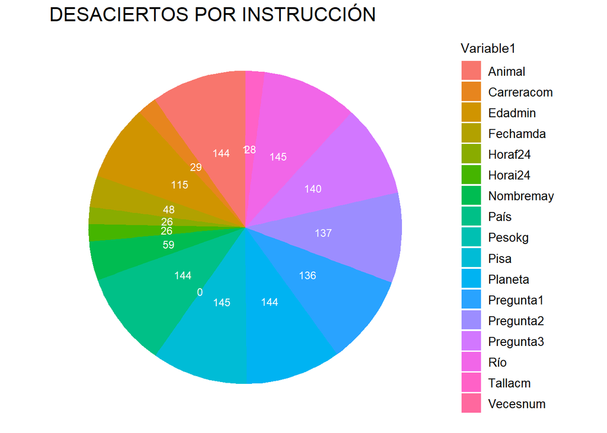

**iii. Relacionar la cantidad de alumnos de la UTEC que no saben seguir instrucciones con el tiempo invertido en el desarrollo de las mismas.**

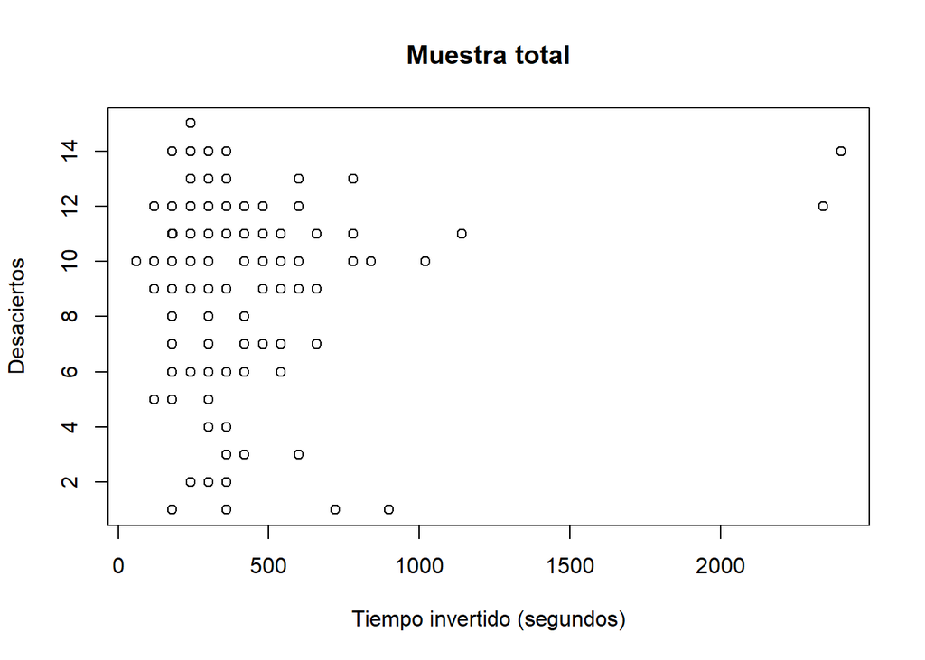

**iv. Relacionar la cantidad de alumnos de la UTEC que no saben seguir instrucciones con la cantidad de alumnos de la UTEC que creen que no saben seguir instrucciones.**

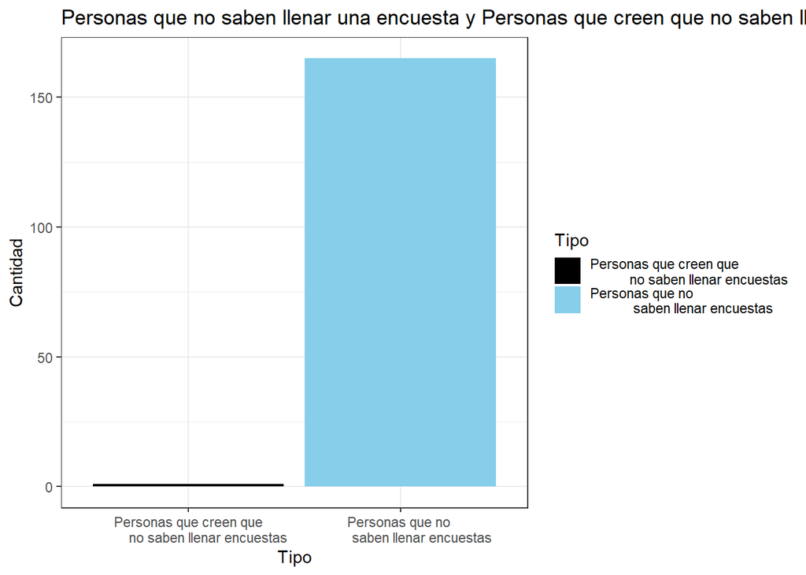

- **Análisis descriptivo:** El gráfico de barras nos muestra la cantidad de personas que creen que no saben llenar encuestas y las personas que no saben llenar encuestas realmente. Respondiendo al objetivo, la relación entre la cantidad de alumnos de la UTEC que no saben seguir instrucciones con la cantidad de alumnos de la UTEC que creen que no saben seguir instrucciones es totalmente opuesta, pues, la cantidad de estudiantes que son conscientes de no saber seguir instrucciones en la encuesta es insignificante en compaarción a la cantidad de estudiantes que no sabe llenar encuestas.

**v. Relacionar la cantidad de alumnos de la UTEC que saben seguir instrucciones con la cantidad de alumnos de la UTEC que creen que saben seguir instrucciones.**

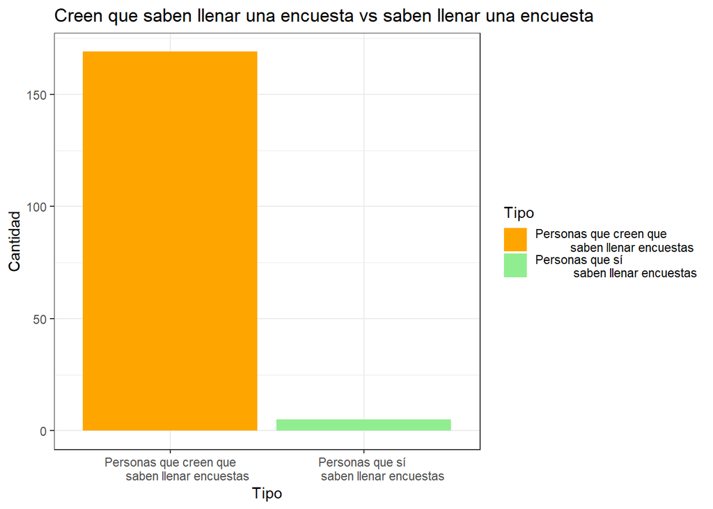

- **Análisis descriptivo:** En este gráfico tenemos la situación contraria al gráfico de barras anterior: personas que creen que sí saben llenar encuestas vs personas que sí saben llenar encuestas; sin embargo, la situación es la misma. Respondiendo al objetivo, la relación entre las variables sigue siendo opuesta e inversamente proporcional. Pues, las personas que sí saben llenar encuestas y lo reconocen, son insignificantes en comparación a las que creen que lo hicieron bien, y en realidad lo hicieron mal.

**vi. Relacionar la cantidad de respuestas correctas e incorrectas por persona, en función del tiempo invertido en el desarrollo total de la encuesta.**

[interactive chart not shown]